# Prob 5 - Checkpoint 3

```r
knitr::opts_chunk$set(echo=TRUE, warning=FALSE, message=FALSE, fig.width=12, fig.height=6)
```

```r
meetings = read.csv("speed-dating2.csv", header=TRUE) %>%
na.omit(meetings)
```

Vamos avaliar primeiramente os valores:

- `gender` : sexo do p1, 0 = mulher
- `samerace` : p1 e p2 são da mesma raça?
- `order` : dos vários encontros realizados em uma noite, esse foi o n-ésimo, segundo essa variável pid : id do participante p2
- `int_corr` : correlação entre os interesses de p1 e p2
- `attr` : quão atraente p1 achou p2
- `sinc` : quão sincero p1 achou p2
- `intel` : quão inteligente p1 achou p2
- `fun` : quão divertido p1 achou p2
- `amb` : quão ambicioso p1 achou p2
- `shar` : quanto p1 achou que compartilha interesses e hobbies com p2
- `like` : no geral, quanto p1 gostou de p2?
- `prob` : que probabiliade p1 acha que p2 tem de querer se encontrar novamente com p- (escala 1-10)
- `dec`: houve match
- difAge : diferença de idade utilizando o modúlo da diferença das variáveis: `age_o`(idade de p2) e `age`(idade de p1)

De maneira geral temos:

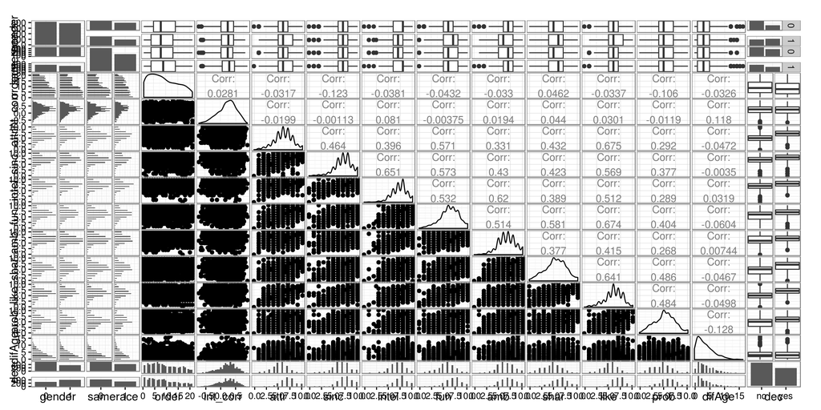

```r
m = meetings %>%
  select(gender,samerace,order,int_corr,attr, sinc, intel, fun, amb, shar,like, prob,dec, age_o, age) %>%
  rowwise %>%
  mutate(difAge = abs(age_o - age)) %>%
  select(gender,samerace,order,int_corr,attr, sinc, intel, fun, amb, shar,like, prob,difAge, dec )

m$dec <- as.factor(m$dec)
m$gender <- as.factor(m$gender)
m$samerace <- as.factor(m$samerace)

ggpairs(m)
```

Como podemos observar, as variáveis `attr`, `like`, `gender` influênciam o match. `attr` e `like` influênciam positivamente, já `gender` tem distribuição distinta, existe mais match se o participante for homem e existe menos macth caso o participante seja mulher.

Vamos tentar observar mais de perto as variáveis individualmente:

Para uma melhor análise iremos utilizar apenas as variáveis em que o intervalo de confiança de match (sim ou não) não se sobrepõe.

Distribuição da variável `attr`

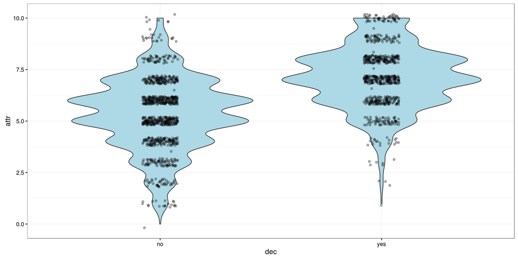

```r
ggplot(m, aes(x = dec, y = attr)) +
  geom_violin(fill = "lightblue") +
  geom_point(position = position_jitter(.2), alpha = .3)
```

```r
gendermodelAttr = glm(dec ~ attr,
                  data = m,
                  family = "binomial")

gendermodelAttr
```

```
##
## Call:  glm(formula = dec ~ attr, family = "binomial", data = m)
##
## Coefficients:
## (Intercept)         attr
##     -4.5142       0.6763
##
## Degrees of Freedom: 1621 Total (i.e. Null);  1620 Residual
## Null Deviance:       2219
## Residual Deviance: 1802  AIC: 1806
```

```r
glance(gendermodelAttr)
```

```
##   null.deviance df.null    logLik      AIC      BIC deviance df.residual
## 1      2218.638    1621 -901.2443 1806.489 1817.271 1802.489        1620
```

```r
pR2(gendermodelAttr)
```

```
##           llh       llhNull            G2      McFadden          r2ML
##  -901.2442664 -1109.3187884   416.1490441     0.1875696     0.2262956
##          r2CU
##     0.3036124
```

Distribuição da variável `like`

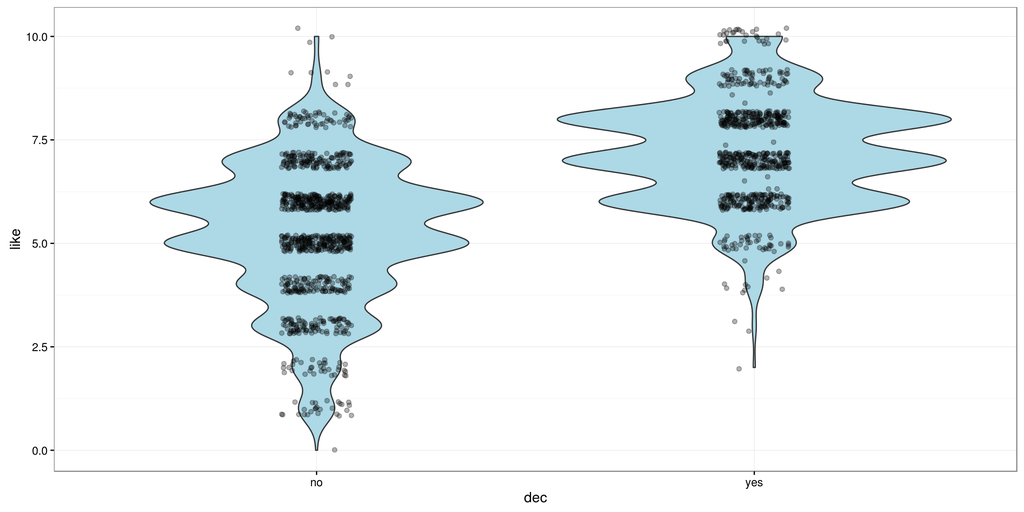

```r
ggplot(m, aes(x = dec, y = like)) +
  geom_violin(fill = "lightblue") +
  geom_point(position = position_jitter(.2), alpha = .3)
```

```r
gendermodelLike = glm(dec ~ like,
                  data = m,
                  family = "binomial")

gendermodelLike
```

```
##
## Call:  glm(formula = dec ~ like, family = "binomial", data = m)
##
## Coefficients:
## (Intercept)         like
##     -6.2119       0.9441
##
## Degrees of Freedom: 1621 Total (i.e. Null);  1620 Residual
## Null Deviance:       2219
## Residual Deviance: 1628  AIC: 1632
```

```r
glance(gendermodelLike)
```

```
##   null.deviance df.null    logLik     AIC      BIC deviance df.residual
## 1      2218.638    1621 -813.9101 1631.82 1642.603  1627.82        1620
```

```r
pR2(gendermodelLike)
```

```
##           llh       llhNull            G2      McFadden          r2ML
##  -813.9100705 -1109.3187884   590.8174360     0.2662974     0.3052842
##          r2CU
##     0.4095885
```

Distribuição da variável `gender`

```r
gendermodelGender= glm(dec ~ gender,
                  data = m,
                  family = "binomial")

gendermodelGender
```

```
##
## Call:  glm(formula = dec ~ gender, family = "binomial", data = m)
##
## Coefficients:
## (Intercept)      gender1
##     -0.6842       0.8242
##
## Degrees of Freedom: 1621 Total (i.e. Null);  1620 Residual
## Null Deviance:       2219
## Residual Deviance: 2152  AIC: 2156
```

```r
glance(gendermodelGender)
```

```
##   null.deviance df.null    logLik      AIC      BIC deviance df.residual
## 1      2218.638    1621 -1076.221 2156.441 2167.224 2152.441        1620
```

```r
pR2(gendermodelGender)
```

```
##           llh       llhNull            G2      McFadden          r2ML
## -1.076221e+03 -1.109319e+03  6.619656e+01  2.983658e-02  3.999011e-02
##          r2CU
##  5.365324e-02
```

Agora iremos fazer uma analise multivariada:

```r
bm <- glm(dec ~ gender + like + attr + gender*like + gender*attr + attr*like,
          data = m,
          family = "binomial")

bm
```

```
##
## Call:  glm(formula = dec ~ gender + like + attr + gender * like + gender *
##     attr + attr * like, family = "binomial", data = m)
##
## Coefficients:
##  (Intercept)       gender1          like          attr  gender1:like
##     -6.58991       0.82312       0.63393       0.13665      -0.03490
## gender1:attr     like:attr
##      0.04348       0.02612
##
## Degrees of Freedom: 1621 Total (i.e. Null);  1615 Residual
## Null Deviance:       2219
## Residual Deviance: 1523  AIC: 1537
```

```r
glance(bm)
```

```
##   null.deviance df.null   logLik      AIC      BIC deviance df.residual
## 1      2218.638    1621 -761.529 1537.058 1574.798 1523.058        1615
```

```r
pR2(bm)
```

```
##           llh       llhNull            G2      McFadden          r2ML
##  -761.5290067 -1109.3187884   695.5795636     0.3135165     0.3487363
##          r2CU
##     0.4678865
```